# Loan Application Status Prediction

```
                                        LOAN APPLICATION APPROVAL STATUS
```

Loans are no longer considered a last resort to buy a sought-after smart phone or a dream house. Over the last decade or so, people have become less hesitant in applying for a loan, whether it is personal, vehicle, education, business, or home – especially when they don’t have a lump sum at their disposal. It also helps that banks and other financial institutions are making it easier for customers and prospective borrowers to get loans with minimal paperwork, quick eligibility checks, and competitive interest rates.

As there is a direct relationship between risk and reward and the quest for profit maximization has given rise to accelerated risk taking for enhanced rewards. Henceforth to increase the business of the bank, banks are trying to get a large number of loan applications. With increase in applications, risk associated with it is also increasing day by day. Credit risk is the biggest risk for banks or financial institutions. It occurs when borrowers or counterparties fail to meet contractual obligations.

While banks cannot be fully protected from credit risk due to the nature of their business model. However, they can lower their exposure in several ways. To lower their risk exposure, they can loan money to people with good credit histories, transact with high-quality counterparties, or own collateral to back up the loans. The decision about whether to grant credit to a certain customer must be evaluated on a case-to-case basis. Each small business that grapples with this issue needs to gather and evaluate financial information, decide whether to grant credit and if so how much. In this situation issue of Credit Risk assessment arises, which helps them to evaluate if a loan applicant could be a defaulter at a later stage, whether they could go ahead and grant the loan or not. This helps the banks to minimize the possible losses and can increase the volume of credits.

It is very difficult to predict the possibility of repayment of loan by the customer. In recent years many researchers worked on loan approval prediction systems. Load Application Status Prediction is a task that can be done based on historical information of the customer and bank. Analysing the dataset already existed regarding the status of the Loan Application and creating a model, could help financial institutions to predict the status of Loan Application.

Here various machine learning algorithms will be used on existing dataset to extract important insides and make a model to predict nearly perfect decision to approve or to reject the loan request of a particular customer. Dataset includes the following details of applicants who have applied for loan:

1. Loan_ID : It is simply a unique application number of the customer.
2. Gender : Sex of the applicant.
3. Married : Marital status of the applicant.
4. Dependents : Number of members in the family, who are dependent on the applicant.
5. Education : Educational qualification of the applicant.
6. Self_Employed : Employment status of the applicant. It is important because repayment capacity depends on the income of the person.
7. ApplicantIncome : Apllicant income is important to calculate EMI to Income Ratio.
8. CoapplicantIncome : A co-applicant is a person who joins in the application of a loan. Having a co-applicant can increase the chances of approval of the application.
9. LoanAmount : Amount of loan applied by the applicant.
10. Loan_Amount_Term : The shorter the repayment period, the more credible would be the applicant.
11. Credit_History : A credit score tells a lot about applicants financial health. Whether applicant paid his/her EMIs on time or not.
12. Property_Area : Area of the property is urban or rural.
13. Loan_Status : Status of the application (Approved or rejected). It is the Target variable here.

> It is a problem of Classification as we have to classify whether the Loan Application Status is 'Yes' or 'No'.

```python
# IMPORTING THE REQUIRED LIBRARIES:

import numpy as np
import pandas as pd
import matplotlib.pyplot as plt
import seaborn as sns
from sklearn.linear_model import LogisticRegression
from sklearn.metrics import accuracy_score
from sklearn.metrics import confusion_matrix,classification_report
from sklearn.model_selection import train_test_split
import warnings
warnings.filterwarnings('ignore')
```

```python
# importing the dataset:

dataset = pd.read_csv("https://raw.githubusercontent.com/dsrscientist/DSData/master/loan_prediction.csv")
```

```python
dataset.head()
```

|  | Loan_ID | Gender | Married | Dependents | Education | Self_Employed | ApplicantIncome | CoapplicantIncome | LoanAmount | Loan_Amount_Term | Credit_History | Property_Area | Loan_Status |
| --- | --- | --- | --- | --- | --- | --- | --- | --- | --- | --- | --- | --- | --- |
| 0 | LP001002 | Male | No | 0 | Graduate | No | 5849 | 0.0 | NaN | 360.0 | 1.0 | Urban | Y |
| 1 | LP001003 | Male | Yes | 1 | Graduate | No | 4583 | 1508.0 | 128.0 | 360.0 | 1.0 | Rural | N |
| 2 | LP001005 | Male | Yes | 0 | Graduate | Yes | 3000 | 0.0 | 66.0 | 360.0 | 1.0 | Urban | Y |
| 3 | LP001006 | Male | Yes | 0 | Not Graduate | No | 2583 | 2358.0 | 120.0 | 360.0 | 1.0 | Urban | Y |
| 4 | LP001008 | Male | No | 0 | Graduate | No | 6000 | 0.0 | 141.0 | 360.0 | 1.0 | Urban | Y |

```python
# checking the shape of the dataset:

dataset.shape
```

```
(614, 13)
```

```python
# Checking the information about the data:

dataset.info()
```

```
<class 'pandas.core.frame.DataFrame'>
RangeIndex: 614 entries, 0 to 613
Data columns (total 13 columns):
 #   Column             Non-Null Count  Dtype
---  ------             --------------  -----
 0   Loan_ID            614 non-null    object
 1   Gender             601 non-null    object
 2   Married            611 non-null    object
 3   Dependents         599 non-null    object
 4   Education          614 non-null    object
 5   Self_Employed      582 non-null    object
 6   ApplicantIncome    614 non-null    int64
 7   CoapplicantIncome  614 non-null    float64
 8   LoanAmount         592 non-null    float64
 9   Loan_Amount_Term   600 non-null    float64
 10  Credit_History     564 non-null    float64
 11  Property_Area      614 non-null    object
 12  Loan_Status        614 non-null    object
dtypes: float64(4), int64(1), object(8)
memory usage: 62.5+ KB
```

- From the above output, we observe that Gender, Married, Dependents, Self_Employed, LoanAmount, Loan_Amount_Term, Credit_History are having NULL values.

-In total there are 13 columns out of which only 5 are numeric and others 8 are categorical variables.

```python
# Finding missing values in each column:

dataset.isnull().sum()
```

```
Loan_ID               0
Gender               13
Married               3
Dependents           15
Education             0
Self_Employed        32
ApplicantIncome       0
CoapplicantIncome     0
LoanAmount           22
Loan_Amount_Term     14
Credit_History       50
Property_Area         0
Loan_Status           0
dtype: int64
```

Number of Missing values of the columns:

Gender: 13, Married: 3, Dependents: 15, Self_Employed: 32, LoanAmount: 22, Loan_Amount_Term: 14, Credit_History: 50

# First, removing missing values of categorical columns :

```python
# 1. Gender :

dataset['Gender'].value_counts()
```

```
Male      489
Female    112
Name: Gender, dtype: int64
```

```python
dataset['Gender'] = dataset.Gender.fillna('Male')
```

```python
dataset['Gender'].value_counts()
```

```
Male      502
Female    112
Name: Gender, dtype: int64
```

```python
# 2. Married, is a categorical column so missing value would be replaced by its mode :

dataset['Married'].value_counts()
```

```
Yes    398
No     213
Name: Married, dtype: int64
```

```python
dataset['Married'] = dataset.Married.fillna('Yes')
```

```python
dataset['Married'].value_counts()
```

```
Yes    401
No     213
Name: Married, dtype: int64
```

```python
# 3. Self_Employed

dataset['Self_Employed'].value_counts()
```

```
No     500
Yes     82
Name: Self_Employed, dtype: int64
```

```python
dataset['Self_Employed'] = dataset.Self_Employed.fillna('No')
```

```python
dataset['Self_Employed'].value_counts()
```

```
No     532
Yes     82
Name: Self_Employed, dtype: int64
```

Now, Removing missing values of numerical columns:

```python
# Removing missing values of LoanAmount by its mean:

dataset.LoanAmount = dataset.LoanAmount.fillna(dataset.LoanAmount.mean())
```

```python
dataset['LoanAmount'].isnull().sum()
```

```
0
```

```python
# Removing missing values of Loan_Amount_Term by its mean:

dataset['Loan_Amount_Term'] = dataset["Loan_Amount_Term"].fillna(dataset['Loan_Amount_Term'].mean())
```

```python
dataset['Loan_Amount_Term'].isnull().sum()
```

```
0
```

```python
#  Dependents, if we see number of dependents should be an integer, however in our dataset its an 'Object' data type:

dataset['Dependents'].value_counts()
```

```
0     345
1     102
2     101
3+     51
Name: Dependents, dtype: int64
```

Here, Dependents are having some values as 3+ which means an individual is having more than 3 dependents.

```python
# With '+' sign we cannot move ahead, so remove the + sign and consider the number of dependents as 3.

dataset['Dependents'] = dataset['Dependents'].str.replace(r'\D', '')
```

```python
dataset['Dependents'].value_counts()
```

```
0    345
1    102
2    101
3     51
Name: Dependents, dtype: int64
```

```python
# checking the data type of Dependents column:

dataset['Dependents'].dtypes
```

```
dtype('O')
```

```python
# changing the data type of Dependents column:

dataset["Dependents"] = dataset["Dependents"].astype(str).astype(float)
```

```python
dataset['Dependents'] .isnull().sum()
```

```
15
```

```python
dataset['Dependents'].dtypes
```

```
dtype('float64')
```

```python
dataset['Dependents'] = dataset['Dependents'].fillna(dataset['Dependents'].mean())
```

```python
dataset['Dependents'] .isnull().sum()
```

```
0
```

```python
# As number of dependents cannot be in float, hence changing the type to int:

dataset['Dependents'] = dataset['Dependents'].astype(int)
```

```python
dataset['Dependents'].value_counts()
```

```
0    360
1    102
2    101
3     51
Name: Dependents, dtype: int64
```

```python
# Credit_History

dataset['Credit_History'].value_counts()
```

```
1.0    475
0.0     89
Name: Credit_History, dtype: int64
```

```python
dataset['Credit_History'].isnull().sum()
```

```
50
```

```python
dataset['Credit_History'] = dataset.Credit_History.fillna(1.0)
```

```python
dataset['Credit_History'].value_counts()
```

```
1.0    525
0.0     89
Name: Credit_History, dtype: int64
```

```python
dataset['Credit_History'].isnull().sum()
```

```
0
```

```python
# now, checking is there any missing values in the dataset:

dataset.isnull().sum()
```

```
Loan_ID              0
Gender               0
Married              0
Dependents           0
Education            0
Self_Employed        0
ApplicantIncome      0
CoapplicantIncome    0
LoanAmount           0
Loan_Amount_Term     0
Credit_History       0
Property_Area        0
Loan_Status          0
dtype: int64
```

SO, WE HAVE SUCCESSFULLY REMOVED ALL THE MISSING VALUES.

# Now, checking for the OUTLIERS:

BOXPLOT

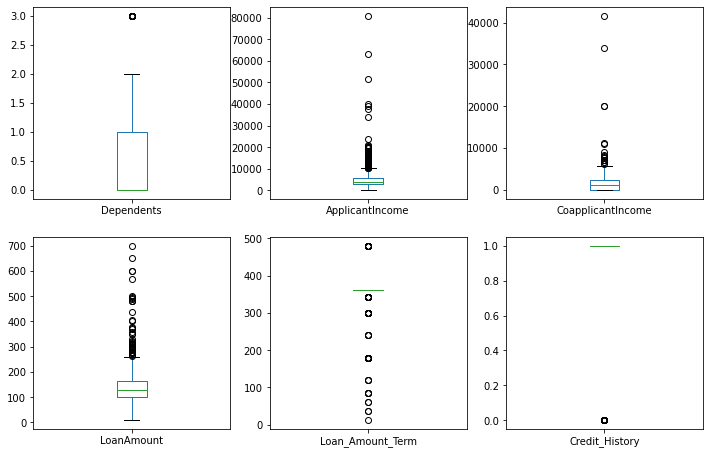

```python
dataset.plot(kind = 'box', figsize = (12,12), layout = (3,3), sharex = False, subplots = True);
```

# Checking the distribution of dataset:

# HISTOGRAM

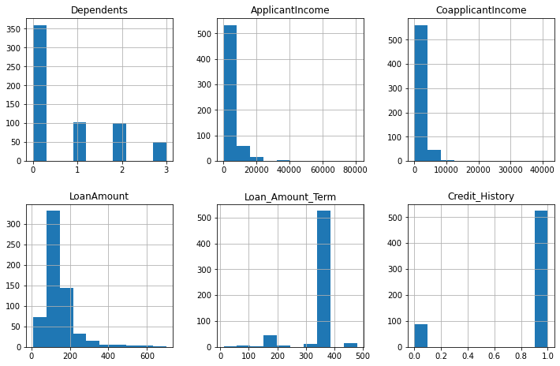

```python
dataset.hist(figsize=(12,12), layout=(3,3), sharex=False);
```

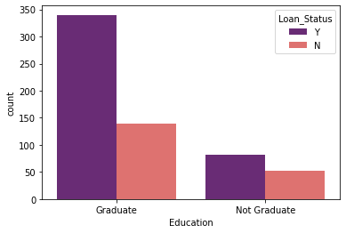

```python
sns.countplot(dataset['Education'], hue = 'Loan_Status', data = dataset, palette = 'magma')
```

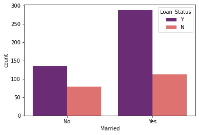

```python
sns.countplot(dataset['Married'], hue = 'Loan_Status', data = dataset, palette = 'magma')
```

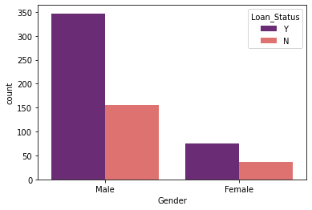

```python
sns.countplot(dataset['Gender'], hue = 'Loan_Status', data = dataset, palette = 'magma')
```

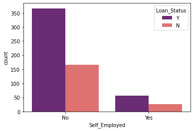

```python
sns.countplot(dataset['Self_Employed'], hue = 'Loan_Status', data = dataset, palette = 'magma')
```

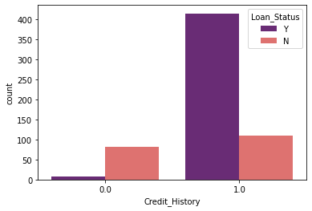

```python
sns.countplot(dataset['Credit_History'], hue = 'Loan_Status', data = dataset, palette = 'magma')
```

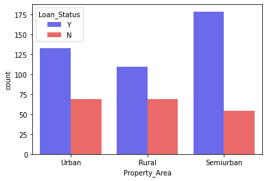

```python
sns.countplot(dataset['Property_Area'], hue = 'Loan_Status', data = dataset, palette = 'seismic')
```

```python
# checking the correlation between variables:

dataset.corr()
```

|  | Dependents | ApplicantIncome | CoapplicantIncome | LoanAmount | Loan_Amount_Term | Credit_History |
| --- | --- | --- | --- | --- | --- | --- |
| Dependents | 1.000000 | 0.118202 | 0.030430 | 0.163106 | -0.101054 | -0.040160 |
| ApplicantIncome | 0.118202 | 1.000000 | -0.116605 | 0.565620 | -0.045242 | -0.018615 |
| CoapplicantIncome | 0.030430 | -0.116605 | 1.000000 | 0.187828 | -0.059675 | 0.011134 |
| LoanAmount | 0.163106 | 0.565620 | 0.187828 | 1.000000 | 0.038801 | -0.001431 |
| Loan_Amount_Term | -0.101054 | -0.045242 | -0.059675 | 0.038801 | 1.000000 | 0.000432 |
| Credit_History | -0.040160 | -0.018615 | 0.011134 | -0.001431 | 0.000432 | 1.000000 |

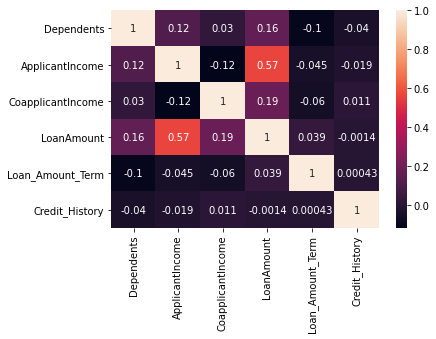

```python
# HEATMAP

sns.heatmap(dataset.corr(), annot=True);
```

Observations from above EDA:

[output not shown]

Dealing with Outliers:

As, we have seen that there are some outliers in our dataset, but here we cannot remove those outliers as the size of our dataset is already small.

CONVERTING CATEGORICAL VARIABLES INTO NUMERIC :

```python
from sklearn.preprocessing import LabelEncoder
```

```python
le = LabelEncoder()

Categorical_feature = ['Gender','Education', 'Married', 'Self_Employed', 'Property_Area', 'Loan_Status']
for i in Categorical_feature:
    dataset[i] = le.fit_transform(dataset[i])
```

```python
dataset.head()
```

|  | Loan_ID | Gender | Married | Dependents | Education | Self_Employed | ApplicantIncome | CoapplicantIncome | LoanAmount | Loan_Amount_Term | Credit_History | Property_Area | Loan_Status |
| --- | --- | --- | --- | --- | --- | --- | --- | --- | --- | --- | --- | --- | --- |
| 0 | LP001002 | 1 | 0 | 0 | 0 | 0 | 5849 | 0.0 | 146.412162 | 360.0 | 1.0 | 2 | 1 |
| 1 | LP001003 | 1 | 1 | 1 | 0 | 0 | 4583 | 1508.0 | 128.000000 | 360.0 | 1.0 | 0 | 0 |
| 2 | LP001005 | 1 | 1 | 0 | 0 | 1 | 3000 | 0.0 | 66.000000 | 360.0 | 1.0 | 2 | 1 |
| 3 | LP001006 | 1 | 1 | 0 | 1 | 0 | 2583 | 2358.0 | 120.000000 | 360.0 | 1.0 | 2 | 1 |
| 4 | LP001008 | 1 | 0 | 0 | 0 | 0 | 6000 | 0.0 | 141.000000 | 360.0 | 1.0 | 2 | 1 |

FEATURE SELECTION:

```python
X = dataset.iloc[:, 1:12]    # Loan id is not of use for the study
Y = dataset.iloc[:, 12]
```

```python
X.head()
```

|  | Gender | Married | Dependents | Education | Self_Employed | ApplicantIncome | CoapplicantIncome | LoanAmount | Loan_Amount_Term | Credit_History | Property_Area |
| --- | --- | --- | --- | --- | --- | --- | --- | --- | --- | --- | --- |
| 0 | 1 | 0 | 0 | 0 | 0 | 5849 | 0.0 | 146.412162 | 360.0 | 1.0 | 2 |
| 1 | 1 | 1 | 1 | 0 | 0 | 4583 | 1508.0 | 128.000000 | 360.0 | 1.0 | 0 |
| 2 | 1 | 1 | 0 | 0 | 1 | 3000 | 0.0 | 66.000000 | 360.0 | 1.0 | 2 |
| 3 | 1 | 1 | 0 | 1 | 0 | 2583 | 2358.0 | 120.000000 | 360.0 | 1.0 | 2 |
| 4 | 1 | 0 | 0 | 0 | 0 | 6000 | 0.0 | 141.000000 | 360.0 | 1.0 | 2 |

```python
Y.head()
```

```
0    1
1    0
2    1
3    1
4    1
Name: Loan_Status, dtype: int32
```

SPLITTING DATA

```python
#now, we will split the dataset into two parts for training and testing in the ratio of 80:20 -

X_train,X_test,Y_train,Y_test = train_test_split(X, Y, test_size = 0.20, random_state = 0 )
```

```python
# to check splitting has been done :

X_test
```

|  | Gender | Married | Dependents | Education | Self_Employed | ApplicantIncome | CoapplicantIncome | LoanAmount | Loan_Amount_Term | Credit_History | Property_Area |
| --- | --- | --- | --- | --- | --- | --- | --- | --- | --- | --- | --- |
| 454 | 1 | 0 | 0 | 0 | 1 | 7085 | 0.0 | 84.0 | 360.0 | 1.0 | 1 |
| 52 | 0 | 0 | 0 | 0 | 0 | 4230 | 0.0 | 112.0 | 360.0 | 1.0 | 1 |
| 536 | 1 | 1 | 0 | 0 | 0 | 6133 | 3906.0 | 324.0 | 360.0 | 1.0 | 2 |
| 469 | 1 | 1 | 0 | 0 | 0 | 4333 | 2451.0 | 110.0 | 360.0 | 1.0 | 2 |
| 55 | 1 | 1 | 2 | 0 | 0 | 2708 | 1167.0 | 97.0 | 360.0 | 1.0 | 1 |
| ... | ... | ... | ... | ... | ... | ... | ... | ... | ... | ... | ... |
| 337 | 1 | 1 | 2 | 0 | 1 | 2500 | 4600.0 | 176.0 | 360.0 | 1.0 | 0 |
| 376 | 1 | 1 | 3 | 0 | 0 | 8750 | 4996.0 | 130.0 | 360.0 | 1.0 | 0 |
| 278 | 1 | 1 | 0 | 0 | 0 | 14583 | 0.0 | 436.0 | 360.0 | 1.0 | 1 |
| 466 | 1 | 1 | 3 | 1 | 0 | 2947 | 1664.0 | 70.0 | 180.0 | 0.0 | 2 |
| 303 | 1 | 1 | 1 | 0 | 0 | 1625 | 1803.0 | 96.0 | 360.0 | 1.0 | 2 |

123 rows × 11 columns

Model Fitting:

1. DecisionTreeClassifier
2. Logistic Regression
3. Random Forest Classifier

```python
#1. DecisionTreeClassifier

from sklearn.tree import DecisionTreeClassifier

# creating Decision Tree classifier object:

model = DecisionTreeClassifier()

# Train Decision Tree Classifier

model.fit(X_train,Y_train)

# prediction of Y_test

Y_pred = model.predict(X_test)
Y_pred
```

```
array([0, 1, 0, 0, 1, 1, 0, 0, 0, 0, 1, 1, 1, 0, 1, 1, 0, 1, 0, 0, 0, 1,
       0, 0, 0, 1, 0, 1, 0, 0, 1, 0, 1, 1, 0, 0, 0, 1, 0, 1, 0, 0, 0, 1,
       1, 1, 1, 1, 1, 1, 1, 1, 1, 0, 0, 0, 1, 0, 1, 1, 0, 0, 1, 0, 1, 1,
       1, 1, 1, 1, 1, 1, 1, 1, 1, 1, 1, 0, 1, 0, 1, 1, 1, 1, 0, 0, 1, 1,
       1, 1, 1, 1, 1, 0, 1, 0, 1, 1, 1, 1, 0, 1, 1, 1, 1, 1, 1, 1, 1, 0,
       1, 1, 0, 0, 0, 0, 1, 1, 1, 1, 1, 0, 1])
```

Model Evaluation

```python
from sklearn import metrics
cnf_matrix = metrics.confusion_matrix(Y_test, Y_pred)
cnf_matrix
```

```
array([[21, 12],
       [25, 65]], dtype=int64)
```

```python
print("Accuracy:", metrics.accuracy_score(Y_test, Y_pred))
```

```
Accuracy: 0.6991869918699187
```

Now, we will check for another model with better accuracy score.

```python
# Fitting Model 2. Logistic Regression

logistic_regression = LogisticRegression()
logistic_regression.fit(X_train, Y_train)
Y_predict = logistic_regression.predict(X_test)
Y_predict
```

```
array([1, 1, 1, 1, 1, 0, 1, 1, 0, 1, 1, 1, 1, 1, 1, 1, 1, 1, 1, 0, 0, 1,
       1, 1, 1, 1, 1, 1, 0, 0, 1, 1, 1, 1, 1, 0, 1, 1, 1, 1, 1, 0, 1, 1,
       1, 1, 1, 1, 1, 1, 1, 1, 1, 1, 1, 1, 1, 1, 1, 1, 0, 1, 1, 0, 1, 1,
       1, 1, 1, 1, 1, 1, 1, 1, 1, 1, 0, 1, 1, 0, 0, 1, 1, 1, 1, 1, 1, 1,
       1, 1, 1, 1, 1, 0, 1, 0, 1, 1, 1, 1, 1, 1, 1, 1, 1, 1, 1, 1, 1, 1,
       1, 1, 1, 1, 0, 0, 1, 1, 1, 1, 1, 0, 1])
```

Model Evaluation using Confusion matrix

```python
cnf_matrix = metrics.confusion_matrix(Y_test, Y_predict)
cnf_matrix
```

```
array([[15, 18],
       [ 3, 87]], dtype=int64)
```

```python
print("Accuracy:", metrics.accuracy_score(Y_test, Y_predict))
```

```
Accuracy: 0.8292682926829268
```

Here, we get the accuracy rate as 82.93% which is much better than DecisionTreeClassifier.

Visualization of Confusion Matrix using Heatmap

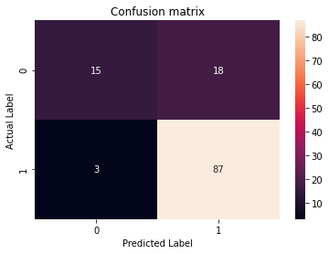

```python
sns.heatmap(cnf_matrix, annot=True)
plt.title('Confusion matrix')
plt.ylabel('Actual Label')
plt.xlabel('Predicted Label')
plt.show()
```

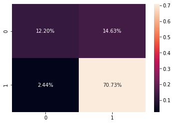

```python
sns.heatmap(cnf_matrix/np.sum(cnf_matrix), annot=True, fmt = '.2%')
```

So, for Loan Application status prediction :

Y_predict = logistic_regression.predict(X_test)

model gives fairly significant results.

```python
# # Fitting Model 3. Random Forest Classifier

from sklearn.ensemble import RandomForestClassifier
rfc = RandomForestClassifier()

model1 = rfc.fit(X_train,Y_train)

Y_predict2 = model1.predict(X_test)
Y_predict2
print("Accuracy:", metrics.accuracy_score(Y_test, Y_predict2))
```

```
Accuracy: 0.7886178861788617
```

```python
cnf_matrix = metrics.confusion_matrix(Y_test, Y_predict2)
cnf_matrix
```

```
array([[14, 19],
       [ 7, 83]], dtype=int64)
```

From above all analysis we find that LogisticRegrssion Model gets the highest accuracy rate as 82.93% .

Conclusion:

```
Logistics Regression model gives the best accuracy out of DecisionTreeClassifier,Logistic Regression,Random Forest Classifier models.
```